# ML practice 2: regression

Сегодня на занятии рассмотрим задачи регресcии

**Ваша очередь:**

- В чем отличие задач регресcии от классификации?
- Задача регрессии – это задача обучения с учителем или обучения без учителя?

### Данные

Работаем с данными про цены на жилье в Бостоне

```r
library(MASS)
#?Boston
```

- `crim` per capita crime rate by town
- `zn` proportion of residential land zoned for lots over 25,000 sq.ft
- `indus` proportion of non-retail business acres per town
- `chas` Charles River dummy variable (= 1 if tract bounds river; 0 otherwise).
- `nox` nitrogen oxides concentration (parts per 10 million).
- `rm` average number of rooms per dwelling.
- `age` proportion of owner-occupied units built prior to 1940.
- `dis` weighted mean of distances to five Boston employment centres.
- `rad` index of accessibility to radial highways.
- `tax` full-value property-tax rate per $10,000.
- `ptratio` pupil-teacher ratio by town.
- `black` 1000(Bk - 0.63)^2 where Bk is the proportion of blacks by town.
- `lstat` lower status of the population (percent).
- `medv` median value of owner-occupied homes in $1000s.

```r
data(Boston)
pander::pandoc.table(head(Boston), split.tables=Inf)
```

| crim | zn | indus | chas | nox | rm | age | dis | rad | tax | ptratio | black | lstat | medv |
| --- | --- | --- | --- | --- | --- | --- | --- | --- | --- | --- | --- | --- | --- |
| 0.00632 | 18 | 2.31 | 0 | 0.538 | 6.575 | 65.2 | 4.09 | 1 | 296 | 15.3 | 396.9 | 4.98 | 24 |
| 0.02731 | 0 | 7.07 | 0 | 0.469 | 6.421 | 78.9 | 4.967 | 2 | 242 | 17.8 | 396.9 | 9.14 | 21.6 |
| 0.02729 | 0 | 7.07 | 0 | 0.469 | 7.185 | 61.1 | 4.967 | 2 | 242 | 17.8 | 392.8 | 4.03 | 34.7 |
| 0.03237 | 0 | 2.18 | 0 | 0.458 | 6.998 | 45.8 | 6.062 | 3 | 222 | 18.7 | 394.6 | 2.94 | 33.4 |
| 0.06905 | 0 | 2.18 | 0 | 0.458 | 7.147 | 54.2 | 6.062 | 3 | 222 | 18.7 | 396.9 | 5.33 | 36.2 |
| 0.02985 | 0 | 2.18 | 0 | 0.458 | 6.43 | 58.7 | 6.062 | 3 | 222 | 18.7 | 394.1 | 5.21 | 28.7 |

Посмотрим на данные:

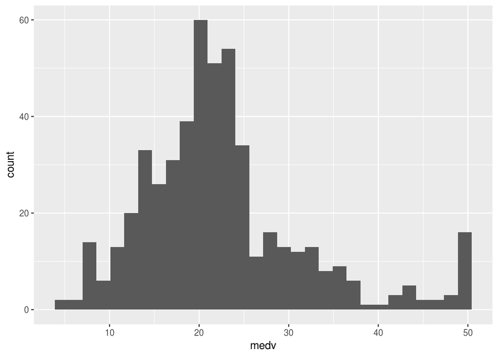

```r
library(ggplot2)
ggplot(data = Boston) + geom_histogram(aes(x = medv))
```

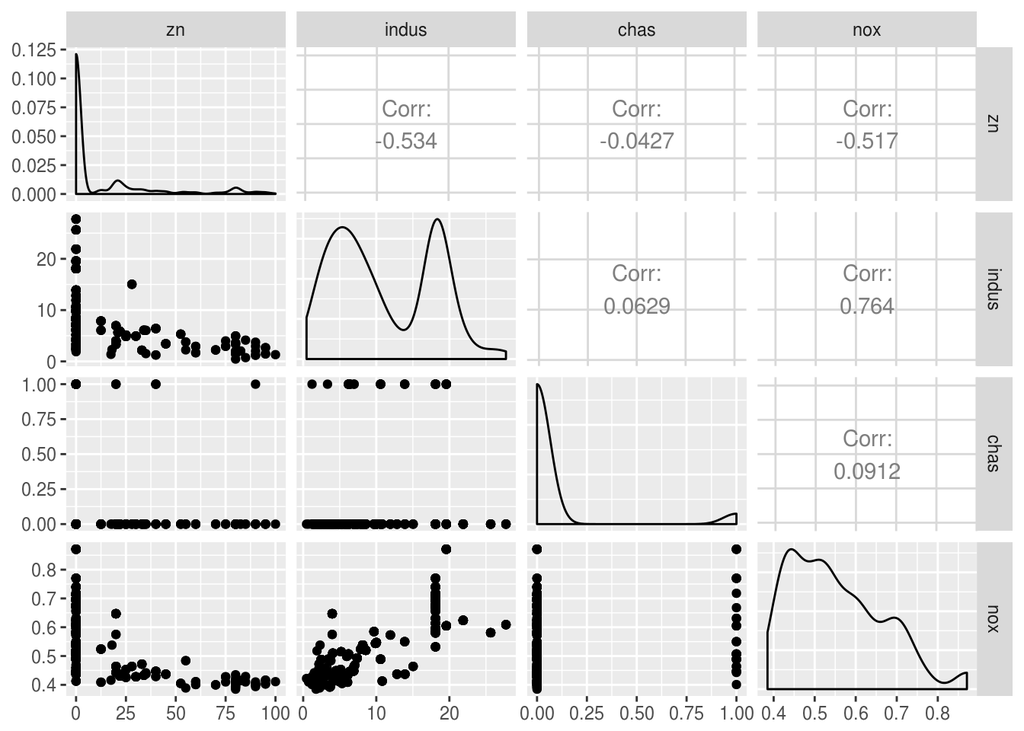

```r
library(GGally)
ggpairs(Boston[, 2:5])
```

- Нужно ли нам логарифмировать предсказываемую переменную `medv`? В каких случаях нужны трансформации?

# Обучающая и тестовая выборки

Отделим 20% от датасета. Как обычно, эта часть не будет использоваться для обучения модели, но на ней мы будем проверять (тестировать), насколько хороша наша модель.

```r
set.seed(6)
Boston.test.ind = sample(seq_len(nrow(Boston)), size = nrow(Boston)*0.2)
Boston.test = Boston[Boston.test.ind,]
Boston.train = Boston[-Boston.test.ind,]
```

### Деревья решений (повторение)

Построение модели

```r
library(partykit)
```

[figure not shown]

```r
modelTree<-ctree(medv~.,data=Boston.train)
plot(modelTree, type = "simple")
```

```r
#plot(modelTree)
```

- Как интерпретировать модель?
- Какие правила можно получить?
- Как делать предсказание на новых данных?

Предсказание на тестовой выборке

```r
tree.predictions <- predict(modelTree, Boston.test)
head(tree.predictions)
```

```
##       307       474       134       192       406       491
## 35.685714 19.930000 16.648214 33.436364  9.323529 16.648214
```

Соответствие предсказанных и реальных значений:

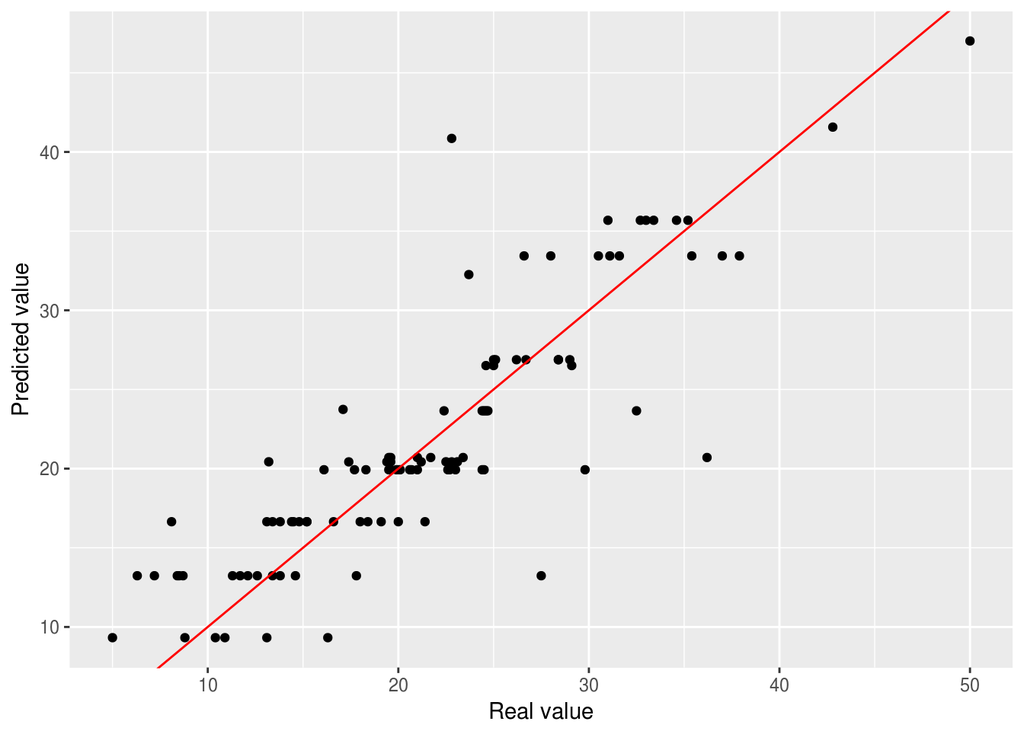

```r
ggplot() + geom_point((aes(x=Boston.test$medv, y=tree.predictions))) +
  geom_abline(color="red") +
  xlab("Real value") +
  ylab("Predicted value")
```

Ошибка предсказания (насколько наше предсказание отличается от фактических значений)

```r
tree.test.RSS = sum((tree.predictions-Boston.test$medv)^2)
tree.test.RSS
```

```
## [1] 1897.266
```

- Что показывает это число?

Одна из особенностей регрессионных деревьев – в качестве предсказания используются всего несколько значений (средние по группам). Существуют и более гибкие инструменты для решения задач регрессии

### Линейная регрессия

Начнем с простой модели (**Simple Linear Regression**) – когда у нас всего один предиктор. В частности, можем ли мы предсказать цену на жилье в районе на основе доли населения с низким социальным статусом (`lstat`)?

В целом, мы хотим приблизить наши данные в виде зависимости $Y = a*X+b$ или в нашем случае $medv = a*lstat+b$, т.е. построить прямую

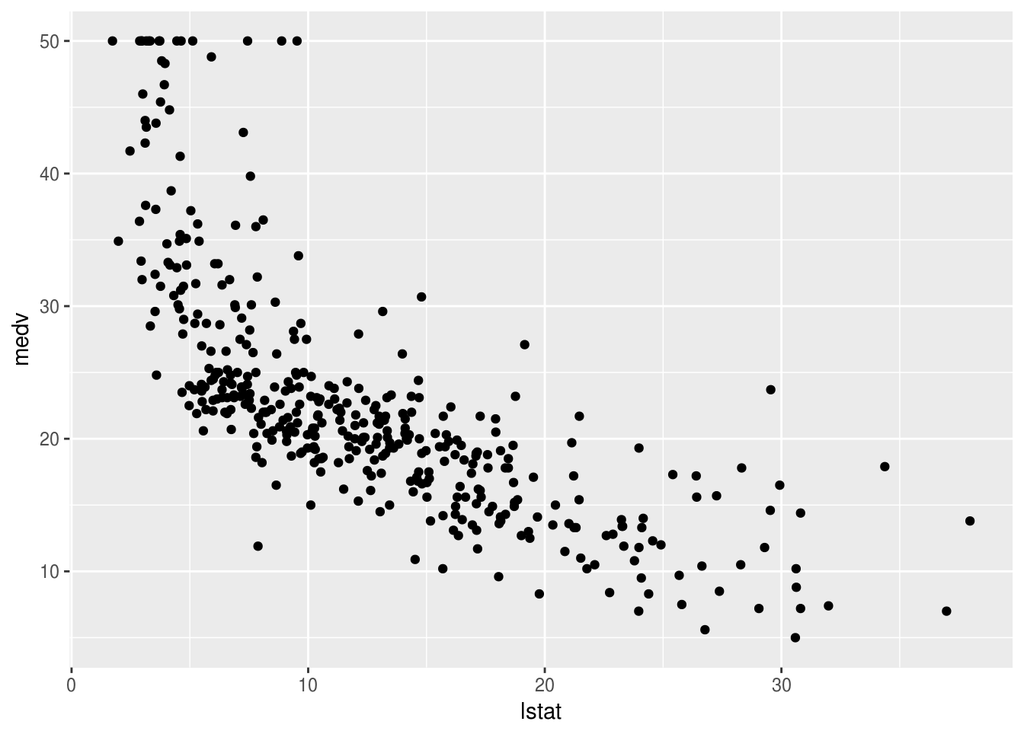

```r
ggplot()+geom_point(data = Boston.train, aes(x = lstat, y = medv))
```

```r
lm.fit=lm(medv~lstat, data=Boston.train)
```

Посмотрим на результат

```r
lm.fit
```

```
##
## Call:
## lm(formula = medv ~ lstat, data = Boston.train)
##
## Coefficients:
## (Intercept)        lstat
##     34.7654      -0.9672
```

Более подробное представление результата

```r
summary(lm.fit)
```

```
##
## Call:
## lm(formula = medv ~ lstat, data = Boston.train)
##
## Residuals:
##     Min      1Q  Median      3Q     Max
## -15.244  -4.110  -1.551   1.845  24.452
##
## Coefficients:
##             Estimate Std. Error t value Pr(>|t|)
## (Intercept) 34.76537    0.65091   53.41   <2e-16 ***
## lstat       -0.96717    0.04574  -21.14   <2e-16 ***
## ---
## Signif. codes:  0 '***' 0.001 '**' 0.01 '*' 0.05 '.' 0.1 ' ' 1
##
## Residual standard error: 6.461 on 403 degrees of freedom
## Multiple R-squared:  0.5259, Adjusted R-squared:  0.5248
## F-statistic: 447.1 on 1 and 403 DF,  p-value: < 2.2e-16
```

Кроме варианта “все сразу в одном выводе” можно использовать и доступ к отдельным элементам, характеризующим построенную модель. Варианты:

```r
names(lm.fit)
```

```
##  [1] "coefficients"  "residuals"     "effects"       "rank"
##  [5] "fitted.values" "assign"        "qr"            "df.residual"
##  [9] "xlevels"       "call"          "terms"         "model"
```

```r
coef(lm.fit)
```

```
## (Intercept)       lstat
##  34.7653656  -0.9671749
```

```r
coef(lm.fit)[1]
```

```
## (Intercept)
##    34.76537
```

ggplot2 позволяет строить регресионные прямые даже без предварительного построения модели

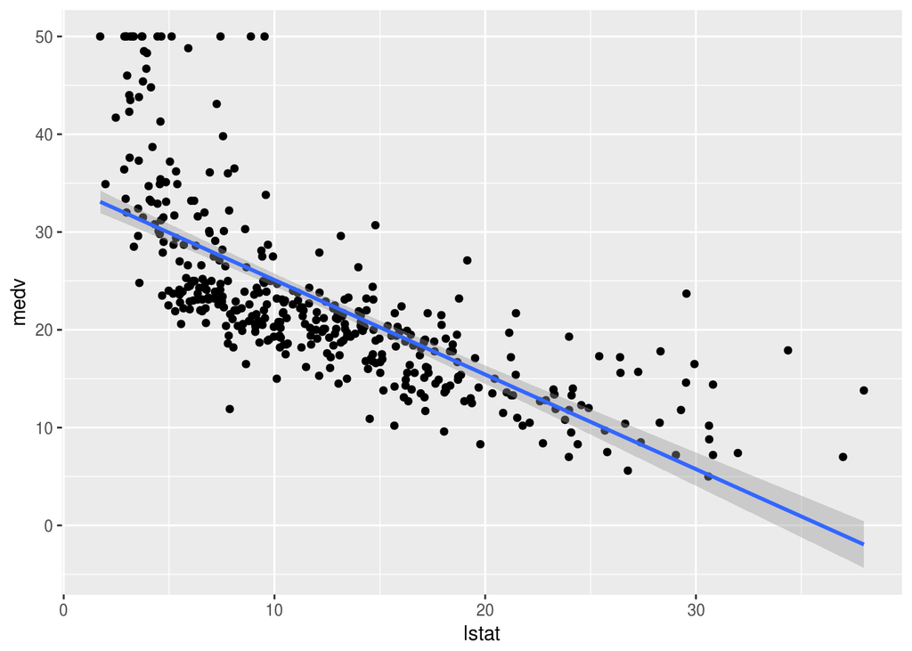

```r
ggplot(data = Boston.train, aes(x = lstat, y = medv))+
  geom_point() +
  geom_smooth(method = "lm", formula = y~x)
```

Для тренировки можем посчитать отклонения и общую ошибку вручную

```r
y = Boston.test$medv # real y values
y_hat = coef(lm.fit)[1] + coef(lm.fit)[2]*Boston.test$lstat #predicted y values

rss = sum((y - y_hat)^2)

y_naive = mean(Boston.test$medv)

tss = sum(((y - y_naive)^2))

1 - (rss/tss) # r^2
```

```
## [1] 0.6254359
```

.. но вручную делать предсказания вообще-то не нужно

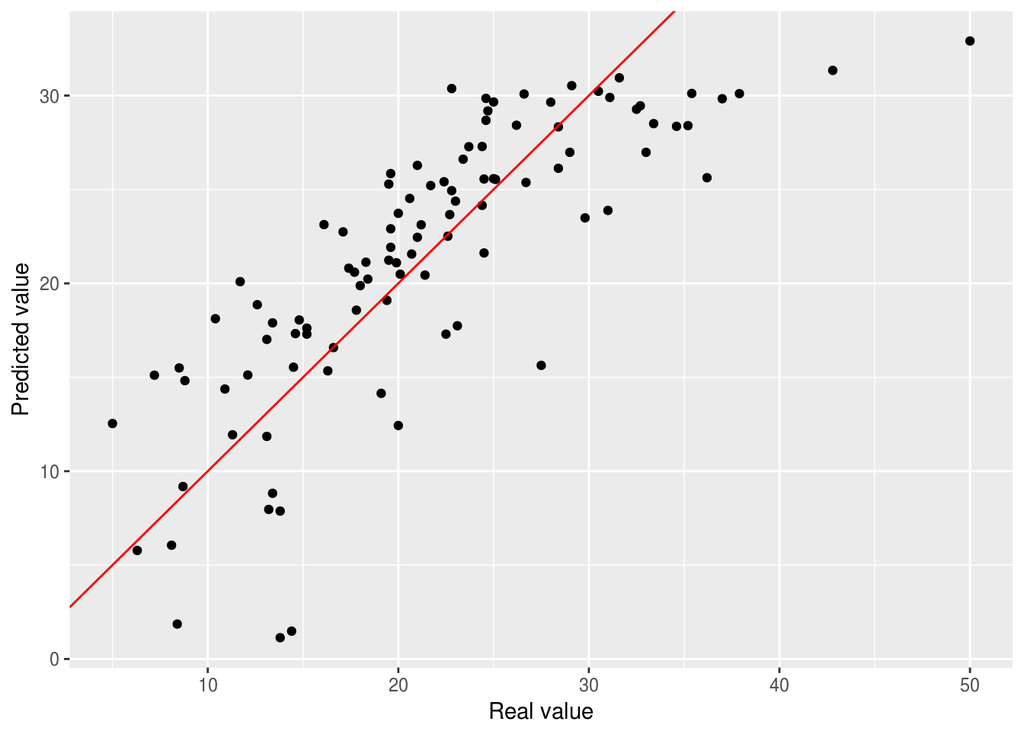

```r
lm.predictions <- predict(lm.fit, Boston.test)

ggplot()+geom_point((aes(x=Boston.test$medv, y=lm.predictions))) +
  geom_abline(color="red") +
  xlab("Real value") +
  ylab("Predicted value")
```

Ошибка предсказания

```r
lm.test.RSS = sum((lm.predictions-Boston.test$medv)^2)
lm.test.RSS
```

```
## [1] 2654.884
```

Переходим к более сложному случаю – когда предикторов несколько (**Multiple Linear Regression**). Например, добавим возраст

```r
lm.fit=lm(medv~lstat+age,data=Boston.train)
summary(lm.fit)
```

```
##
## Call:
## lm(formula = medv ~ lstat + age, data = Boston.train)
##
## Residuals:
##     Min      1Q  Median      3Q     Max
## -16.316  -4.062  -1.432   1.857  22.679
##
## Coefficients:
##             Estimate Std. Error t value Pr(>|t|)
## (Intercept) 32.98726    0.84172  39.190  < 2e-16 ***
## lstat       -1.07579    0.05606 -19.190  < 2e-16 ***
## age          0.04586    0.01400   3.275  0.00115 **
## ---
## Signif. codes:  0 '***' 0.001 '**' 0.01 '*' 0.05 '.' 0.1 ' ' 1
##
## Residual standard error: 6.385 on 402 degrees of freedom
## Multiple R-squared:  0.5383, Adjusted R-squared:  0.536
## F-statistic: 234.3 on 2 and 402 DF,  p-value: < 2.2e-16
```

Или, что более правильно – логарифм возраста (почему?)

```r
lm.fit=lm(medv~lstat+log(age),data=Boston.train)
summary(lm.fit)
```

```
##
## Call:
## lm(formula = medv ~ lstat + log(age), data = Boston.train)
##
## Residuals:
##     Min      1Q  Median      3Q     Max
## -16.105  -4.115  -1.406   1.782  23.353
##
## Coefficients:
##             Estimate Std. Error t value Pr(>|t|)
## (Intercept) 28.75243    2.26952  12.669  < 2e-16 ***
## lstat       -1.04227    0.05288 -19.709  < 2e-16 ***
## log(age)     1.69974    0.61504   2.764  0.00598 **
## ---
## Signif. codes:  0 '***' 0.001 '**' 0.01 '*' 0.05 '.' 0.1 ' ' 1
##
## Residual standard error: 6.409 on 402 degrees of freedom
## Multiple R-squared:  0.5348, Adjusted R-squared:  0.5325
## F-statistic:   231 on 2 and 402 DF,  p-value: < 2.2e-16
```

Или все переменные

```r
lm.fit=lm(medv~.,data=Boston.train)
summary(lm.fit)
```

```
##
## Call:
## lm(formula = medv ~ ., data = Boston.train)
##
## Residuals:
##     Min      1Q  Median      3Q     Max
## -15.896  -2.778  -0.589   1.528  24.354
##
## Coefficients:
##               Estimate Std. Error t value Pr(>|t|)
## (Intercept)  39.333957   5.829973   6.747 5.46e-11 ***
## crim         -0.068299   0.056748  -1.204 0.229491
## zn            0.054013   0.015223   3.548 0.000435 ***
## indus         0.010441   0.068629   0.152 0.879156
## chas          2.715445   1.016126   2.672 0.007847 **
## nox         -18.176751   4.353078  -4.176 3.67e-05 ***
## rm            3.531637   0.469788   7.518 3.85e-13 ***
## age           0.010707   0.015102   0.709 0.478767
## dis          -1.612945   0.226542  -7.120 5.21e-12 ***
## rad           0.381849   0.079075   4.829 1.97e-06 ***
## tax          -0.015342   0.004320  -3.552 0.000429 ***
## ptratio      -0.980043   0.144038  -6.804 3.83e-11 ***
## black         0.011249   0.003099   3.630 0.000321 ***
## lstat        -0.589025   0.058806 -10.016  < 2e-16 ***
## ---
## Signif. codes:  0 '***' 0.001 '**' 0.01 '*' 0.05 '.' 0.1 ' ' 1
##
## Residual standard error: 4.841 on 391 degrees of freedom
## Multiple R-squared:  0.7418, Adjusted R-squared:  0.7332
## F-statistic: 86.42 on 13 and 391 DF,  p-value: < 2.2e-16
```

Регрессионный анализ имеет ряд предположений и ограничений и, соответственно, различных тестов, которые проверяют эти ограничения. Один из них – проверка мультиколлинеарности (взаимосвязи между некоторыми предикторами).

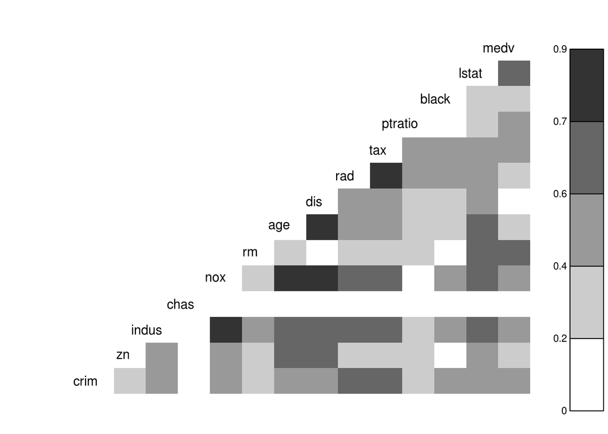

```r
arm::corrplot(Boston.train)
```

```r
car::vif(lm.fit)
```

```
##     crim       zn    indus     chas      nox       rm      age      dis
## 2.482024 2.274908 3.738903 1.072023 4.367926 1.992762 3.112416 3.911177
##      rad      tax  ptratio    black    lstat
## 7.877010 8.716507 1.748233 1.398802 2.944717
```

Один из методов проверки – переменная подозрительна на мультиколлинеарность, если $\sqrt{VIF} > 2$, более мягкая версия $VIF > 10$

```r
sqrt(car::vif(lm.fit)) > 2
```

```
##    crim      zn   indus    chas     nox      rm     age     dis     rad
##   FALSE   FALSE   FALSE   FALSE    TRUE   FALSE   FALSE   FALSE    TRUE
##     tax ptratio   black   lstat
##    TRUE   FALSE   FALSE   FALSE
```

Удаляем переменные из модели

```r
lm.fit1=lm(medv~.-rad-tax-nox,data=Boston.train)
summary(lm.fit1)
```

```
##
## Call:
## lm(formula = medv ~ . - rad - tax - nox, data = Boston.train)
##
## Residuals:
##      Min       1Q   Median       3Q      Max
## -17.6942  -2.8692  -0.5046   1.6414  26.9706
##
## Coefficients:
##             Estimate Std. Error t value Pr(>|t|)
## (Intercept) 20.60851    4.88934   4.215 3.10e-05 ***
## crim         0.01118    0.05029   0.222 0.824253
## zn           0.04428    0.01540   2.875 0.004263 **
## indus       -0.14232    0.06058  -2.349 0.019297 *
## chas         3.06948    1.05053   2.922 0.003680 **
## rm           4.07864    0.47912   8.513 3.61e-16 ***
## age         -0.01175    0.01499  -0.784 0.433672
## dis         -1.36118    0.22491  -6.052 3.33e-09 ***
## ptratio     -0.73838    0.13409  -5.507 6.60e-08 ***
## black        0.01199    0.00318   3.769 0.000189 ***
## lstat       -0.59067    0.06117  -9.656  < 2e-16 ***
## ---
## Signif. codes:  0 '***' 0.001 '**' 0.01 '*' 0.05 '.' 0.1 ' ' 1
##
## Residual standard error: 5.045 on 394 degrees of freedom
## Multiple R-squared:  0.7175, Adjusted R-squared:  0.7103
## F-statistic: 100.1 on 10 and 394 DF,  p-value: < 2.2e-16
```

Можно вносить изменения в уже построенную модель

```r
lm.fit1=update(lm.fit1, ~.-age)
summary(lm.fit1)
```

```
##
## Call:
## lm(formula = medv ~ crim + zn + indus + chas + rm + dis + ptratio +
##     black + lstat, data = Boston.train)
##
## Residuals:
##      Min       1Q   Median       3Q      Max
## -17.5968  -2.8917  -0.5157   1.5823  26.5669
##
## Coefficients:
##              Estimate Std. Error t value Pr(>|t|)
## (Intercept) 20.320664   4.873140   4.170 3.75e-05 ***
## crim         0.012415   0.050245   0.247 0.804975
## zn           0.045961   0.015248   3.014 0.002742 **
## indus       -0.148526   0.060029  -2.474 0.013771 *
## chas         3.039465   1.049322   2.897 0.003982 **
## rm           4.007063   0.470106   8.524 3.31e-16 ***
## dis         -1.293348   0.207488  -6.233 1.17e-09 ***
## ptratio     -0.738650   0.134020  -5.512 6.43e-08 ***
## black        0.011861   0.003174   3.737 0.000214 ***
## lstat       -0.608943   0.056529 -10.772  < 2e-16 ***
## ---
## Signif. codes:  0 '***' 0.001 '**' 0.01 '*' 0.05 '.' 0.1 ' ' 1
##
## Residual standard error: 5.042 on 395 degrees of freedom
## Multiple R-squared:  0.717,  Adjusted R-squared:  0.7106
## F-statistic: 111.2 on 9 and 395 DF,  p-value: < 2.2e-16
```

**Трансформация предикторов**

Вернемся с простой модели

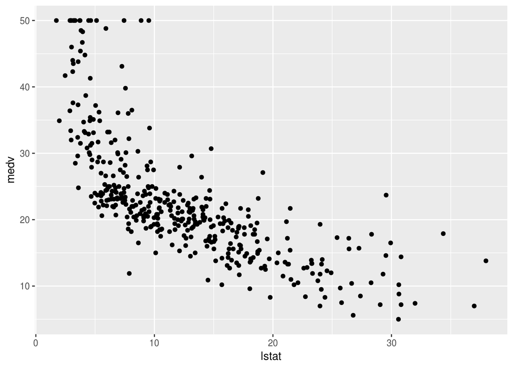

```r
ggplot()+geom_point(data = Boston.train, aes(x = lstat, y = medv))
```

Можно заметить, что зависимость не линейная. Отразим это в модели

```r
lm.fit2=lm(medv~lstat+I(lstat^2), data=Boston.train)
summary(lm.fit2)
```

```
##
## Call:
## lm(formula = medv ~ lstat + I(lstat^2), data = Boston.train)
##
## Residuals:
##      Min       1Q   Median       3Q      Max
## -15.2512  -4.0379  -0.4935   2.4412  25.4933
##
## Coefficients:
##              Estimate Std. Error t value Pr(>|t|)
## (Intercept) 43.230111   1.006827   42.94   <2e-16 ***
## lstat       -2.402445   0.145385  -16.52   <2e-16 ***
## I(lstat^2)   0.045936   0.004467   10.28   <2e-16 ***
## ---
## Signif. codes:  0 '***' 0.001 '**' 0.01 '*' 0.05 '.' 0.1 ' ' 1
##
## Residual standard error: 5.756 on 402 degrees of freedom
## Multiple R-squared:  0.6247, Adjusted R-squared:  0.6228
## F-statistic: 334.6 on 2 and 402 DF,  p-value: < 2.2e-16
```

*Функция I() нужна для того, чтобы действительно произошло воведение в квадрат, т.к. символ ^ в формуле означает пересечение: (a + b)^2 = a + b + a:b*

Сравним с первоначальной моделью (на обучающей выборке)

```r
lm.fit0=lm(medv~lstat, data=Boston.train)
anova(lm.fit0,lm.fit2) # так можно сравнить на обучающей выборке
```

```
## Analysis of Variance Table
##
## Model 1: medv ~ lstat
## Model 2: medv ~ lstat + I(lstat^2)
##   Res.Df   RSS Df Sum of Sq      F    Pr(>F)
## 1    403 16825
## 2    402 13320  1    3504.7 105.77 < 2.2e-16 ***
## ---
## Signif. codes:  0 '***' 0.001 '**' 0.01 '*' 0.05 '.' 0.1 ' ' 1
```

На тестовой выборке

```r
lm.predictions2 <- predict(lm.fit2, Boston.test)
lm.test.RSS2 = sum((lm.predictions2-Boston.test$medv)^2)
lm.test.RSS2
```

```
## [1] 2040.337
```

А значение для первоначальной модели было

```r
lm.test.RSS
```

```
## [1] 2654.884
```

**Ваша очередь:**

- Посчитайте ошибки для моделей с большим числом предикторов. Какая лучше?
- Постройте регрессионые модели для данных о продаже (`Sales`) детских кресел

```r
library(ISLR)
data(Carseats)
```

```r
?Carseats
```

```r
pander::pandoc.table(head(Carseats), split.tables=Inf)
```

| Sales | CompPrice | Income | Advertising | Population | Price | ShelveLoc | Age | Education | Urban | US |
| --- | --- | --- | --- | --- | --- | --- | --- | --- | --- | --- |
| 9.5 | 138 | 73 | 11 | 276 | 120 | Bad | 42 | 17 | Yes | Yes |
| 11.22 | 111 | 48 | 16 | 260 | 83 | Good | 65 | 10 | Yes | Yes |
| 10.06 | 113 | 35 | 10 | 269 | 80 | Medium | 59 | 12 | Yes | Yes |
| 7.4 | 117 | 100 | 4 | 466 | 97 | Medium | 55 | 14 | Yes | Yes |
| 4.15 | 141 | 64 | 3 | 340 | 128 | Bad | 38 | 13 | Yes | No |
| 10.81 | 124 | 113 | 13 | 501 | 72 | Bad | 78 | 16 | No | Yes |

- Какая модель дает лучшее предсказание на тестовой выборке? Какие предикторы в нее входят?
- Какие продажи будут в регионе с населением 200 тысяч, уровнем образования 16 и доходом $75000 при тратах на рекламу $2000 (все остальные значения берутся средними по выборке)?